# PSTAT 131 - Final Project

Haodong Yan (9638180)

Dec 02, 2022

# Introduction

The purpose of this project is to generate a model that will be able to predict the credit card payment status based on the application record and credit record of the credit card user.

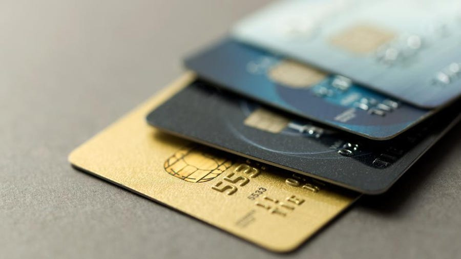

### Credit Scores

Credit score cards are a common risk control method in the banking systems. It uses personal information and historical records from credit card applicants to analyze the “credibility” of credit card holders. Using this information, banks are able to determine the kinds of actions to take for people with different creditworthiness.

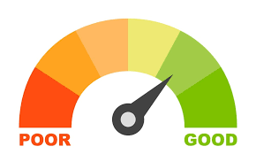

### How my model can be helpful

This model can be helpful by helping credit companies predict the potential credit performance of a user based on their application data, finding out whether or not an applicant is eligible for their application.

# Loading Data

### Packages and Seed

```r
library(dplyr)
library(tidymodels)
library(tidyverse)
library(ggplot2)
library(corrplot)
library(janitor)
library(ISLR)
library(rpart.plot)
library(vip)
library(randomForest)
library(xgboost)
library(parsnip)
library(ranger)
library(tibble)
library(ggcorrplot)
library(caret)
library(klaR)
library(pROC)
library(discrim)
library(pROC)
tidymodels_prefer()
set.seed(0213)
```

### Raw Data

The raw data is obtain from [Credit Card Approval Prediction (Cleaned Version)](https://www.kaggle.com/datasets/caesarmario/application-data) on Kaggle, which is a dataset derived from [Credit Card Approval Prediction](https://www.kaggle.com/datasets/rikdifos/credit-card-approval-prediction) datasets.

```r
applications_raw = read.csv("data/Application_Data.csv")
applications_raw = applications_raw %>% clean_names()
head(applications_raw)
```

```
##   applicant_id applicant_gender owned_car owned_realty total_children
## 1      5008806          M               1            1              0
## 2      5008808          F               0            1              0
## 3      5008809          F               0            1              0
## 4      5008810          F               0            1              0
## 5      5008811          F               0            1              0
## 6      5008815          M               1            1              0
##   total_income                                        income_type
## 1       112500 Working
## 2       270000 Commercial associate
## 3       270000 Commercial associate
## 4       270000 Commercial associate
## 5       270000 Commercial associate
## 6       270000 Working
##                                       education_type
```

[output cut: 41 more lines]

```r
dim(applications_raw)
```

```
## [1] 25128    21
```

There are 25128 applicants and 21 information attributes to each one of them.

```r
summary(applications_raw)
```

```
##   applicant_id     applicant_gender     owned_car       owned_realty
##  Min.   :5008806   Length:25128       Min.   :0.0000   Min.   :0.0000
##  1st Qu.:5042226   Class :character   1st Qu.:0.0000   1st Qu.:0.0000
##  Median :5079004   Mode  :character   Median :0.0000   Median :1.0000
##  Mean   :5078835                      Mean   :0.4184   Mean   :0.6549
##  3rd Qu.:5115603                      3rd Qu.:1.0000   3rd Qu.:1.0000
##  Max.   :5150487                      Max.   :1.0000   Max.   :1.0000
##  total_children    total_income     income_type        education_type
##  Min.   :0.0000   Min.   :  27000   Length:25128       Length:25128
##  1st Qu.:0.0000   1st Qu.: 135000   Class :character   Class :character
##  Median :0.0000   Median : 180000   Mode  :character   Mode  :character
##  Mean   :0.5095   Mean   : 194837
##  3rd Qu.:1.0000   3rd Qu.: 225000
##  Max.   :5.0000   Max.   :1575000
##  family_status      housing_type       owned_mobile_phone owned_work_phone
##  Length:25128       Length:25128       Min.   :1          Min.   :0.0000
##  Class :character   Class :character   1st Qu.:1          1st Qu.:0.0000
##  Mode  :character   Mode  :character   Median :1          Median :0.0000
##                                        Mean   :1          Mean   :0.2738
##                                        3rd Qu.:1          3rd Qu.:1.0000
##                                        Max.   :1          Max.   :1.0000
##   owned_phone      owned_email      job_title         total_family_members
##  Min.   :0.0000   Min.   :0.0000   Length:25128       Min.   :1.000
##  1st Qu.:0.0000   1st Qu.:0.0000   Class :character   1st Qu.:2.000
##  Median :0.0000   Median :0.0000   Mode  :character   Median :2.000
##  Mean   :0.2927   Mean   :0.1007                      Mean   :2.291
##  3rd Qu.:1.0000   3rd Qu.:0.0000                      3rd Qu.:3.000
##  Max.   :1.0000   Max.   :1.0000                      Max.   :7.000
##  applicant_age years_of_working total_bad_debt    total_good_debt
##  Min.   :21    Min.   : 1.000   Min.   : 0.0000   Min.   : 1.00
##  1st Qu.:33    1st Qu.: 3.000   1st Qu.: 0.0000   1st Qu.: 9.00
##  Median :40    Median : 6.000   Median : 0.0000   Median :18.00
##  Mean   :41    Mean   : 7.691   Mean   : 0.3331   Mean   :21.06
##  3rd Qu.:48    3rd Qu.:10.000   3rd Qu.: 0.0000   3rd Qu.:31.00
##  Max.   :68    Max.   :44.000   Max.   :49.0000   Max.   :61.00
##      status
##  Min.   :0.0000
##  1st Qu.:1.0000
##  Median :1.0000
##  Mean   :0.9952
##  3rd Qu.:1.0000
##  Max.   :1.0000
```

Here are some of the key variables that are helpful to be aware of for this report, check the codebook for the complete version:

- `applicant_id`: Client number
- `applicant_gender`: Gender
- `owned_car`: Whether or not the applicant owned a car
- `total_income`: Annual income
- `income_type`: Income category
- `family_status`: Marital status
- `total_family_members`: Family size
- `job_title`: Job title
- `applicant_age`: Age
- `years_of_working:` Years worked
- `total_bad_debt`: Total amount of bad debts. Bad Debt: loan is 30 or more days overdue.
- `total_good_debt`: Total amount of good debts. Good Debt: loan is 30 or less days overdue/ paid on time/ no loan for that month.
- `status`: If the total of Good Debt is higher than Bad Debt, then an applicant status will be eligible (1). If the total of Bad Debt is higher than Good Debt, then an applicant status will be not eligible (0).

### Data Cleaning

The data has been cleaned by [@Mario Caesar](https://www.kaggle.com/caesarmario), but further actions on cleaning data needs to be taken as well.

`applicant_id` is not important for building our models; the value for `owned_mobile_phone` is always 1.

```r
applications = applications_raw %>%
  select(-applicant_id, -owned_mobile_phone)
head(applications)
```

```
##   applicant_gender owned_car owned_realty total_children total_income
## 1          M               1            1              0       112500
## 2          F               0            1              0       270000
## 3          F               0            1              0       270000
## 4          F               0            1              0       270000
## 5          F               0            1              0       270000
## 6          M               1            1              0       270000
##                                          income_type
## 1 Working
## 2 Commercial associate
## 3 Commercial associate
## 4 Commercial associate
## 5 Commercial associate
## 6 Working
##                                       education_type
```

[output cut: 41 more lines]

#### Redefining Status

Redefine Status to applicant having 15% or more debts as bad debts will be considered not eligible(value 0), having 15% or less as bad debts will be eligible(value 1). I did this because the original standard is too high that most people will likely be eligible for the application. Also, remove total_bad_debt and total_good_debt as they determines the value of status

```r
applications = applications %>% mutate(status = ifelse(total_bad_debt/(total_bad_debt+total_good_debt) < 0.15, 1, 0)) %>%
  select(-total_bad_debt,-total_good_debt)
```

Factor all the categorical variables

```r
applications = applications %>% mutate(applicant_gender = factor(applicant_gender), owned_car  = factor(owned_car), owned_realty = factor(owned_realty), income_type = factor(income_type), education_type = factor(education_type), family_status = factor(family_status), housing_type =factor(housing_type), owned_work_phone = factor(owned_work_phone), owned_phone =factor(owned_phone), owned_email = factor(owned_email), job_title = factor(job_title), status = factor(status))

head(applications)
```

```
##   applicant_gender owned_car owned_realty total_children total_income
## 1          M               1            1              0       112500
## 2          F               0            1              0       270000
## 3          F               0            1              0       270000
## 4          F               0            1              0       270000
## 5          F               0            1              0       270000
## 6          M               1            1              0       270000
##                                          income_type
## 1 Working
## 2 Commercial associate
## 3 Commercial associate
## 4 Commercial associate
## 5 Commercial associate
## 6 Working
##                                       education_type
```

[output cut: 34 more lines]

Now I am finished with data cleaning, and here is a summary of the data.

```r
summary(applications)
```

```
##  applicant_gender owned_car owned_realty total_children    total_income
##  F      :15627    0:14615   0: 8671      Min.   :0.0000   Min.   :  27000
##  M      : 9501    1:10513   1:16457      1st Qu.:0.0000   1st Qu.: 135000
##                                          Median :0.0000   Median : 180000
##                                          Mean   :0.5095   Mean   : 194837
##                                          3rd Qu.:1.0000   3rd Qu.: 225000
##                                          Max.   :5.0000   Max.   :1575000
##
##                                              income_type
##  Commercial associate                              : 7052
##  Pensioner                                         :   13
##  State servant                                     : 2437
##  Student                                           :   10
##  Working                                           :15616
##
##
##                                             education_type
##  Academic degree                                   :   14
##  Higher education                                  : 7132
##  Incomplete higher                                 :  993
##  Lower secondary                                   :  187
##  Secondary / secondary special                     :16802
##
##
##                                             family_status
##  Civil marriage                                    : 2133
##  Married                                           :17507
##  Separated                                         : 1464
##  Single / not married                              : 3444
##  Widow                                             :  580
##
##
##                                              housing_type   owned_work_phone
##  Co-op apartment                                   :  152   0:18249
##  House / apartment                                 :22096   1: 6879
##  Municipal apartment                               :  812
##  Office apartment                                  :  199
##  Rented apartment                                  :  439
##  With parents                                      : 1430
##
```

[output cut: 9 more lines]

```
##  Laborers                                          :6211   Min.   :1.000
##  Core staff                                        :3591   1st Qu.:2.000
##  Sales staff                                       :3485   Median :2.000
##  Managers                                          :3012   Mean   :2.291
##  Drivers                                           :2135   3rd Qu.:3.000
##  High skill tech staff                             :1383   Max.   :7.000
##  (Other)                                           :5311
##  applicant_age years_of_working status
##  Min.   :21    Min.   : 1.000   0:  864
##  1st Qu.:33    1st Qu.: 3.000   1:24264
##  Median :40    Median : 6.000
##  Mean   :41    Mean   : 7.691
##  3rd Qu.:48    3rd Qu.:10.000
##  Max.   :68    Max.   :44.000
##
```

```r
dim(applications)
```

```
## [1] 25128    17
```

### Data Split

I choose to split the data into 70% training set and 30% testing set.

```r
applications_split = initial_split(applications, prop = 0.7, strata = status)
applications_train = training(applications_split)
applications_test = testing(applications_split)


dim(applications_train)
```

```
## [1] 17589    17
```

```r
dim(applications_test)
```

```
## [1] 7539   17
```

```r
dim(applications_train)[1] / dim(applications)[1]
```

```
## [1] 0.6999761
```

```r
dim(applications_train) + dim(applications_test)
```

```
## [1] 25128    34
```

The ratio between training and testing set is approximately 7:3, and has the right number of total observations. The split is appropriate.

# Exploratory Data Analysis

I am doing analysis in only the training set.

There are 17589 observations and 17 variables in the training set.

Number of observations for each status

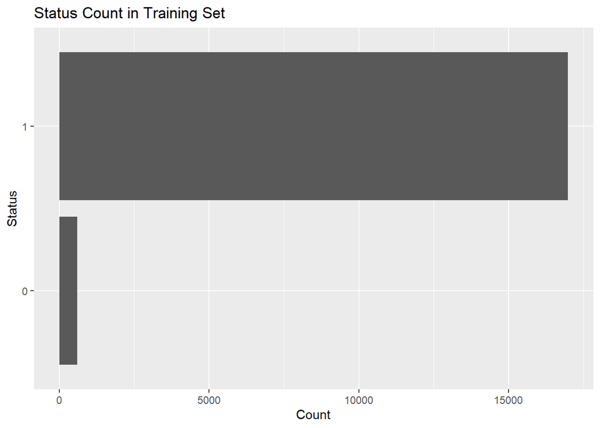

```r
applications_train %>% ggplot(aes(status)) + geom_bar() + labs(title = "Status Count in Training Set", x = "Status", y = "Count") + coord_flip()
```

Not many applicants have an non-eligible(0) status.

Status by Gender

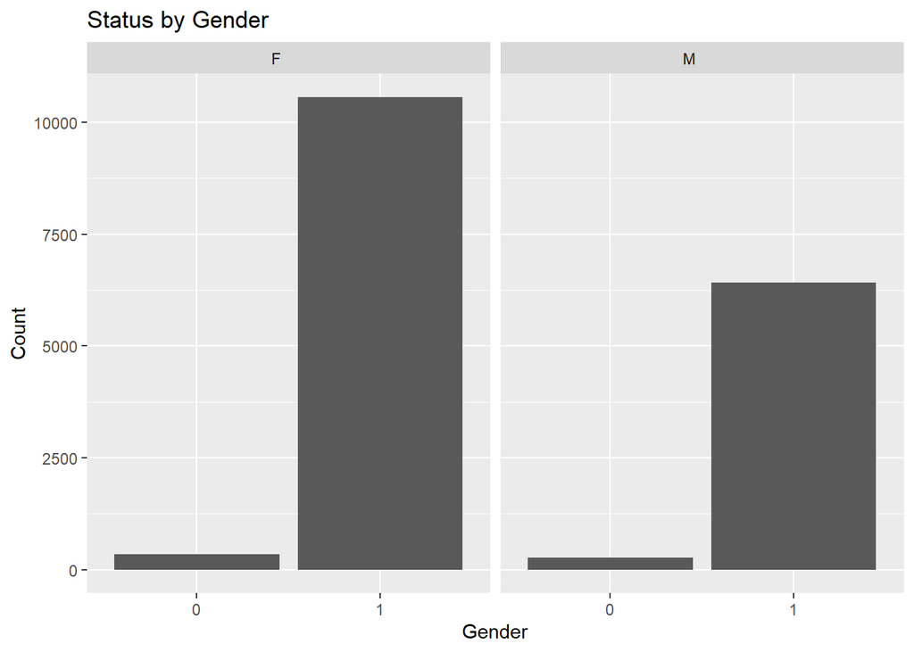

```r
applications_train %>%
  group_by(status,applicant_gender) %>% count %>%
  ggplot(aes(status, n)) + geom_col(show.legend = FALSE) + facet_wrap(~applicant_gender) + labs(title = "Status by Gender", y = "Count", x = "Gender")
```

There are less males than females, but the ratio of non-eligible(0) status to eligible(1) status is greater for males.

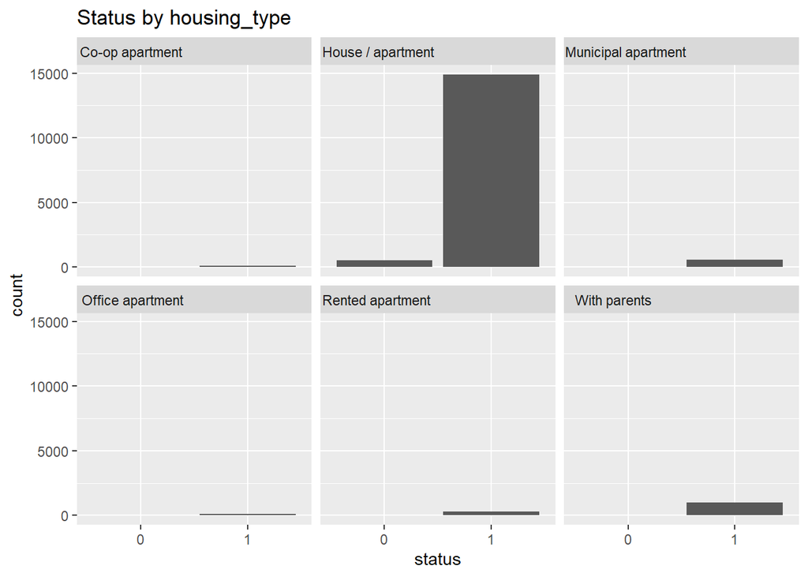

```r
applications_train %>%
  ggplot(aes(status)) +
  geom_histogram(stat="count") +
  facet_wrap(~housing_type) +
  labs(
    title = "Status by housing_type")
```

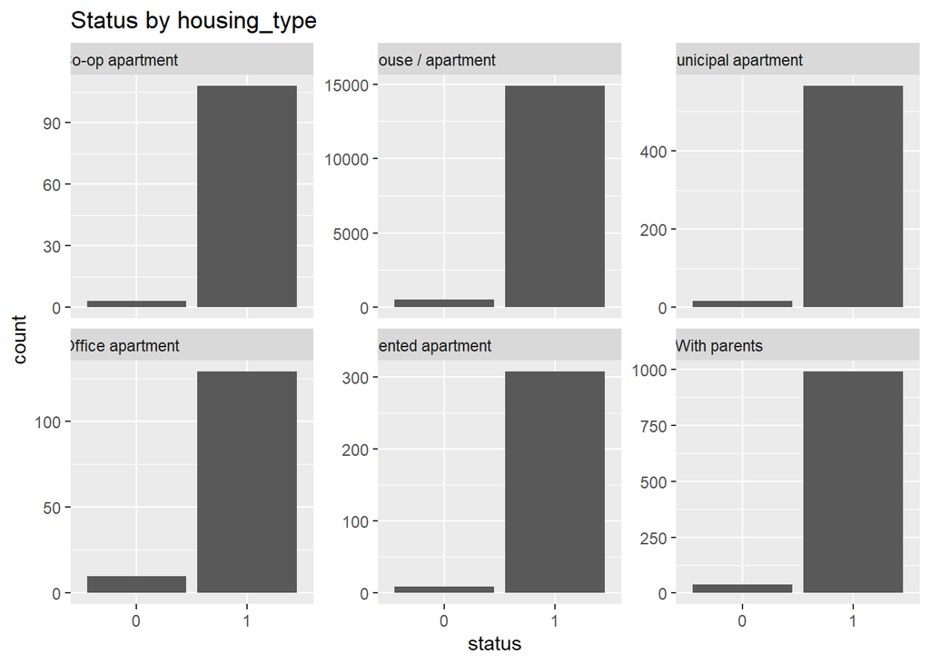

```r
applications_train %>%
  filter(status %in% c(0,1)) %>%
  ggplot(aes(status)) +
  geom_histogram(stat="count") +
  facet_wrap(~housing_type, scales = "free_y") +
  labs(
    title = "Status by housing_type")
```

Different housing type have different amount of applicants/ observations. House/ apartment has the highest amount of observations.

Age distribution

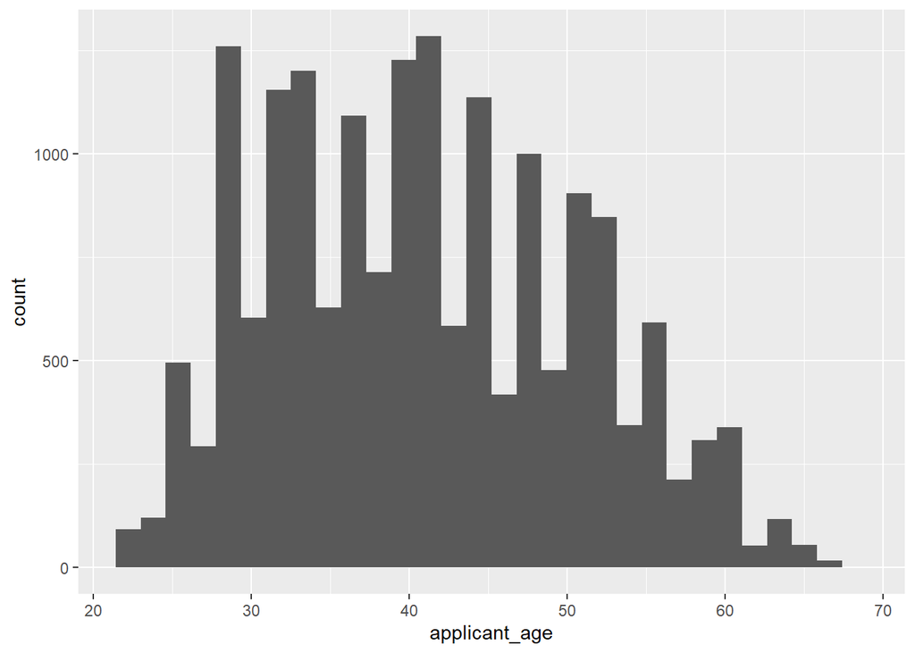

```r
ggplot(applications_train, aes(applicant_age)) +
  geom_histogram()
```

Most applicants are from 25-60 years old.

Finding correlations between different numeric variables

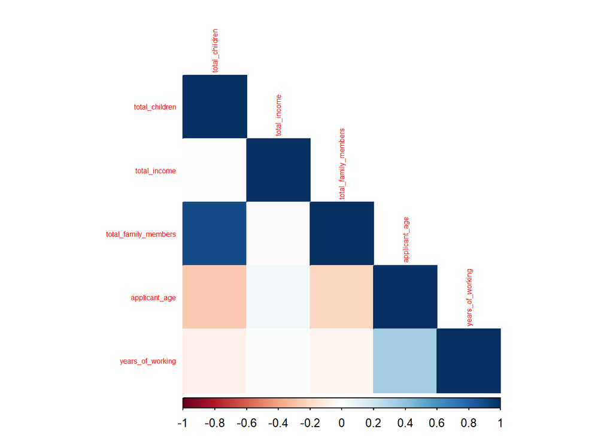

```r
applications_train %>%
  select(is.numeric) %>%
  cor() %>%
  corrplot(type = "lower",  method = 'color', tl.cex = 0.5)
```

The plot shows that there is a strong positive relationship between total_children and total_family_members. It makes sense because the amount of family members heavily depends on the number of the children ub the family.

# Model Building

## Cross Validation

I fold the training set using v-fold cross-validation, with v = 5. Stratify on the outcome variable.

```r
applications_fold = vfold_cv(data = applications_train, v = 5, strata = status)
```

## Recipe building

Since I have cleaned the data before and discarded variables that are not useful for building our models, I can just use all the variables in my formula for the recipe.

```r
applications_recipe = recipe(status~ applicant_gender+owned_car+owned_realty+total_children+total_income+income_type+education_type+family_status+housing_type+owned_work_phone+owned_phone+owned_email+job_title+total_family_members+applicant_age+years_of_working, applications_train) %>%
  step_impute_linear(total_children, impute_with = imp_vars(total_family_members)) %>%
  step_dummy(all_nominal_predictors())  %>%
  step_normalize(all_predictors())
```

I dummy-coded all nominal predictors and centered and scaled all predictors. I also used step_impute_linear because of the strong correlation between total_children and total_family_members.

# Models

## Model 1

Since this is a classification problem with binary outputs, I will test out the accuracy of Logistic Regression model and LDA on the training data. Then fit the most accurate model with the testing data and Find the accuracy of it.

### Logistic Regression Fit

Fitting a logistic regression with the glm engine

```r
log_reg = logistic_reg() %>%
  set_engine("glm") %>%
  set_mode("classification")

log_wflow = workflow() %>%
  add_model(log_reg) %>%
  add_recipe(applications_recipe)

log_fit = fit_resamples(resamples = applications_fold,log_wflow, control = control_resamples(save_pred = TRUE))
```

### LDA Fit

Fitting a linear discriminant analysis with the MASS engine

```r
lda = discrim_linear() %>%
  set_mode("classification") %>%
  set_engine("MASS")

lda_wflow = workflow() %>%
  add_model(lda) %>%
  add_recipe(applications_recipe)

lda_fit = fit_resamples(resamples = applications_fold,lda_wflow, control = control_resamples(save_pred = TRUE))
```

There are 5 folds for each type of model, which brings a total of 10 models for both of the models.

### Comparing the Model Performance

```r
collect_metrics(log_fit)
```

```
## # A tibble: 2 × 6
##   .metric  .estimator  mean     n  std_err .config
##   <chr>    <chr>      <dbl> <int>    <dbl> <chr>
## 1 accuracy binary     0.965     5 0.000992 Preprocessor1_Model1
## 2 roc_auc  binary     0.568     5 0.00714  Preprocessor1_Model1
```

```r
collect_metrics(lda_fit)
```

```
## # A tibble: 2 × 6
##   .metric  .estimator  mean     n std_err .config
##   <chr>    <chr>      <dbl> <int>   <dbl> <chr>
## 1 accuracy binary     0.965     5 0.00113 Preprocessor1_Model1
## 2 roc_auc  binary     0.569     5 0.00681 Preprocessor1_Model1
```

### Fitting the testing data

```r
log_fit_a = fit(log_wflow, applications_train)

log_predict = predict(log_fit_a, new_data = applications_test, type = "class")  %>%
  bind_cols(applications_test %>% select(status)) %>%
  accuracy(truth = status, estimate = .pred_class)
```

### Fitting the testing data on LDA

Out of curiosity, I will be testing the accuracy of LDA on the testing data

```r
lda_fit_a = fit(lda_wflow, applications_train)

lda_predict = predict(lda_fit_a, new_data = applications_test, type = "class")  %>%
  bind_cols(applications_test %>% select(status)) %>%
  accuracy(truth = status, estimate = .pred_class)
```

## Model 2

The next method I decided to use is Elastic Net Tuning. It is one of the major regularization methods.

### Elastic Net Tuning

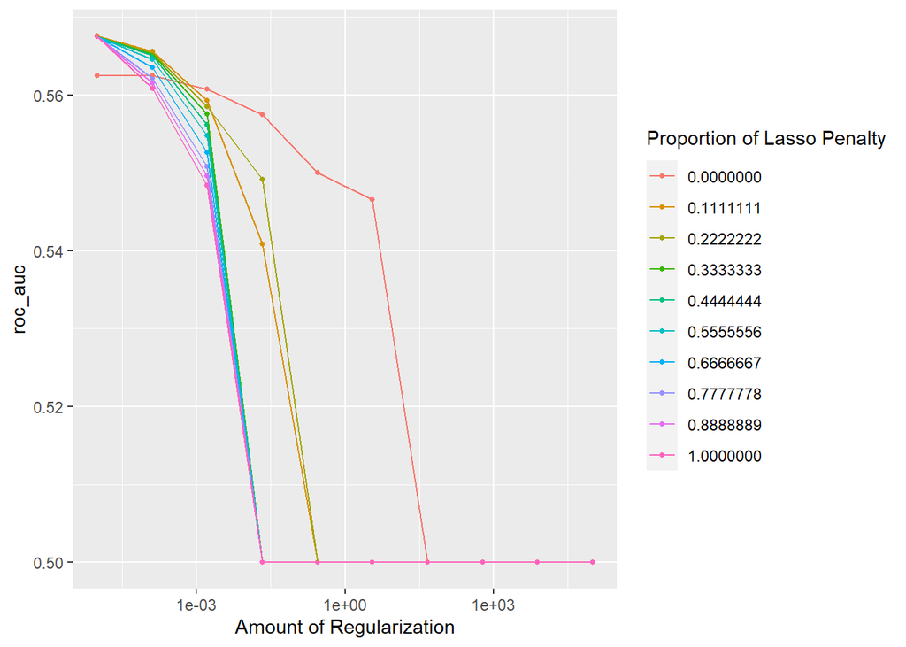

```r
elastic = multinom_reg(penalty = tune(), mixture = tune()) %>%
  set_mode("classification") %>%
  set_engine("glmnet")

elastic_workflow = workflow() %>%
  add_recipe(applications_recipe) %>%
  add_model(elastic)

elastic_grid = grid_regular(penalty(range = c(-5, 5)), mixture(range = c(0,1)), levels = 10)

tune_res = tune_grid(
  elastic_workflow,
  resamples = applications_fold,
  grid = elastic_grid,
  metrics = metric_set(roc_auc)
)
autoplot(tune_res)
```

### Fitting the optimal Model

```r
best = select_best(tune_res)
elastic_final_wflow = finalize_workflow(elastic_workflow, best)
elastic_final_fit = fit(elastic_final_wflow, data = applications_train)

elastic_predict = predict(elastic_final_fit, new_data = applications_test, type = "class")  %>%
  bind_cols(applications_test %>% select(status)) %>%
  accuracy(truth = status, estimate = .pred_class)

elastic_ROCAUC = augment(elastic_final_fit, new_data = applications_test) %>%
  select(status, starts_with(".pred"))
```

# Model 3

For the third models, random forest for our model.

### Random Forest

```r
tree_spec = rand_forest() %>%
  set_engine("ranger", importance = "impurity") %>%
  set_mode("classification")

class_tree_fit = tree_spec %>%
  fit(status~ applicant_gender+owned_car+owned_realty+total_children+total_income+income_type+education_type+family_status+housing_type+owned_work_phone+owned_phone+owned_email+job_title+total_family_members+applicant_age+years_of_working, data = applications_train)

class_tree_wf = workflow() %>%
  add_model(tree_spec %>% set_args(mtry = tune(), trees = tune(), min_n = tune())) %>%
  add_formula(status~ applicant_gender+owned_car+owned_realty+total_children+total_income+income_type+education_type+family_status+housing_type+owned_work_phone+owned_phone+owned_email+job_title+total_family_members+applicant_age+years_of_working)

regular_grid = grid_regular(mtry(range = c(1,16)), trees(range = c(1,500)), min_n(range = c(1,30)), levels = 4)
```

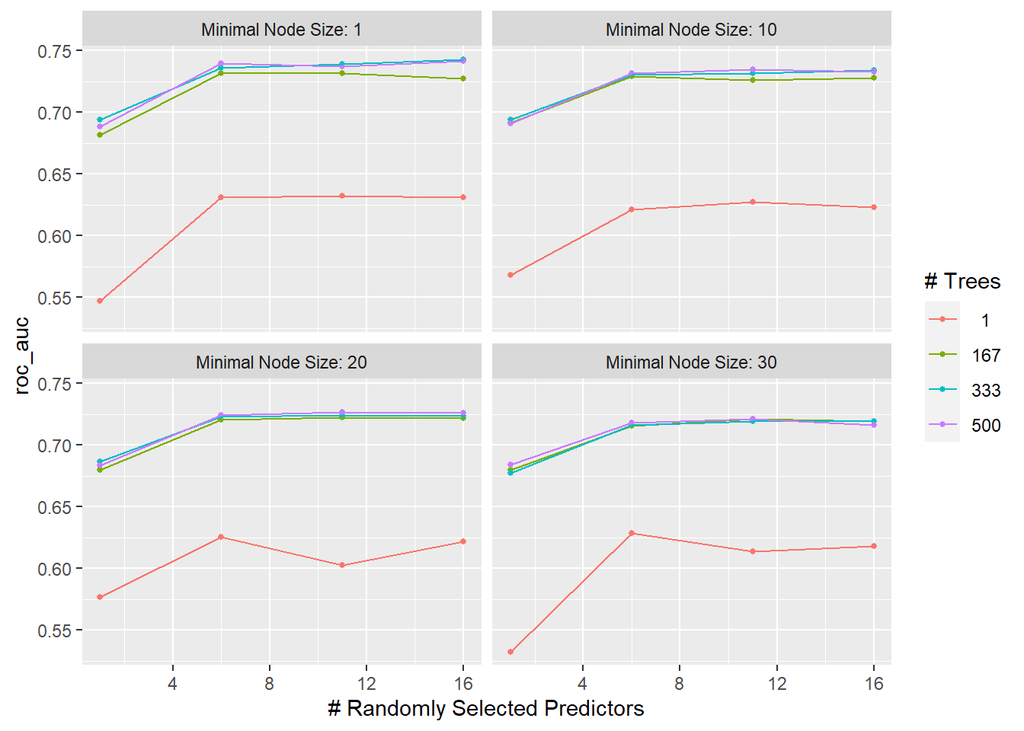

```r
tree_res = tune_grid(
  class_tree_wf,
  resamples = applications_fold,
  grid = regular_grid,
  metrics = metric_set(roc_auc)
)

autoplot(tree_res)
```

Now we can find the best tuning values for the random forest.

```r
tree_res %>%
  collect_metrics() %>%
  arrange(by_group = desc(mean))
```

```
## # A tibble: 64 × 9
##     mtry trees min_n .metric .estimator  mean     n std_err .config
##    <int> <int> <int> <chr>   <chr>      <dbl> <int>   <dbl> <chr>
##  1    16   333     1 roc_auc binary     0.743     5 0.00875 Preprocessor1_Model…
##  2    16   500     1 roc_auc binary     0.742     5 0.00757 Preprocessor1_Model…
##  3     6   500     1 roc_auc binary     0.739     5 0.00599 Preprocessor1_Model…
##  4    11   333     1 roc_auc binary     0.739     5 0.0107  Preprocessor1_Model…
##  5    11   500     1 roc_auc binary     0.737     5 0.0110  Preprocessor1_Model…
##  6     6   333     1 roc_auc binary     0.736     5 0.00743 Preprocessor1_Model…
##  7    11   500    10 roc_auc binary     0.735     5 0.00770 Preprocessor1_Model…
##  8    16   333    10 roc_auc binary     0.734     5 0.00856 Preprocessor1_Model…
##  9    16   500    10 roc_auc binary     0.733     5 0.00922 Preprocessor1_Model…
## 10     6   500    10 roc_auc binary     0.732     5 0.00689 Preprocessor1_Model…
## # … with 54 more rows
```

We can see the importance of each variable by creating a variable importance plot

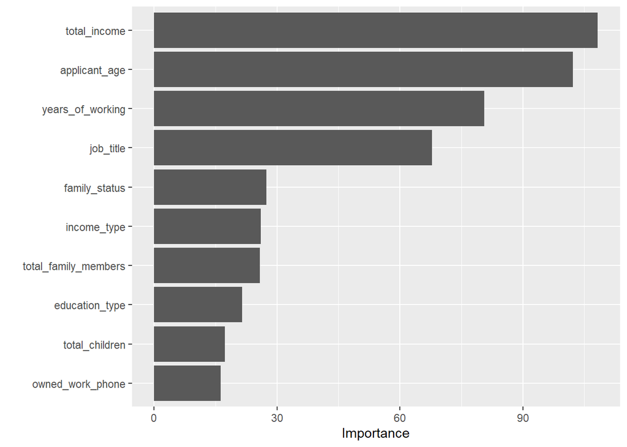

```r
class_tree_fit %>%
  extract_fit_engine() %>%
  vip()
```

We can uses these value to find the best model fit.

```r
best_trees = select_best(tree_res)

tree_forest_final = finalize_workflow(class_tree_wf, best_trees)

tree_forest_final_fit = fit(tree_forest_final, data = applications_train)

tree_forest_predict = predict(tree_forest_final_fit, new_data = applications_test, type = "class")  %>%
  bind_cols(applications_test %>% select(status)) %>%
  accuracy(truth = status, estimate = .pred_class)

tree_forest_ROCAUC = augment(tree_forest_final_fit, new_data = applications_test) %>%
  select(status, starts_with(".pred"))
```

# Model 4

For the final model, I am going to use Boosted Trees Regression. It is a method similar to the bagging method, or the regular random forest method, but build trees sequentially instead of parallel.

### Boosted Trees

```r
boost_spec = boost_tree(tree_depth = 4) %>%
  set_engine("xgboost") %>%
  set_mode("classification")

boost_fit = fit(boost_spec, status~ applicant_gender+owned_car+owned_realty+total_children+total_income+income_type+education_type+family_status+housing_type+owned_work_phone+owned_phone+owned_email+job_title+total_family_members+applicant_age+years_of_working, data = applications_train)

boost_wf = workflow() %>%
  add_model(boost_spec %>% set_args(trees = tune())) %>%
  add_formula(status~ applicant_gender+owned_car+owned_realty+total_children+total_income+income_type+education_type+family_status+housing_type+owned_work_phone+owned_phone+owned_email+job_title+total_family_members+applicant_age+years_of_working)

boost_grid = grid_regular(trees(range = c(10,400)), levels = 5)
```

For tuning values, I gave the trees a range from 10 to 400 to cover a wider range of number of trees in the ensemble. I set the levels to 5 to control the computational power needed.

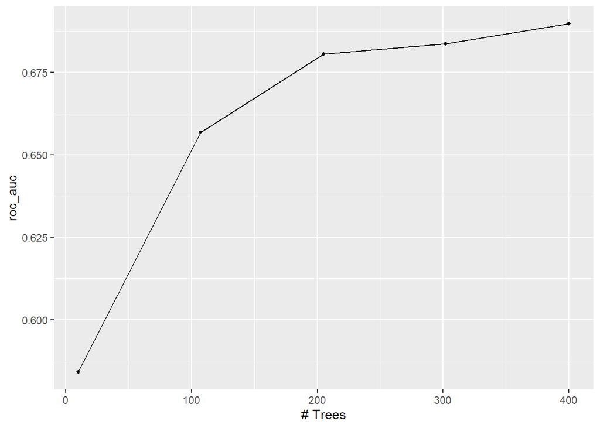

```r
tune_boosted = tune_grid(
  boost_wf,
  resamples = applications_fold,
  grid = boost_grid,
  metrics = metric_set(roc_auc)
)
autoplot(tune_boosted)
```

Then we find the best tuning value for the boosted tree

```r
best_boosted = select_best(tune_boosted)

boosted_trees_final_wf = finalize_workflow(boost_wf, best_boosted)

boosted_trees_final_fit = fit(boosted_trees_final_wf, data = applications_train)

boosted_trees_predict = predict(boosted_trees_final_fit, new_data = applications_test, type = "class")  %>%
  bind_cols(applications_test %>% select(status)) %>%
  accuracy(truth = status, estimate = .pred_class)

boost_trees_ROCAUC = augment(boosted_trees_final_fit, new_data = applications_test) %>%
  select(status, starts_with(".pred"))
```

# Comparing Different Models

```r
accuracies = bind_rows(log_predict,lda_predict,elastic_predict,tree_forest_predict, boosted_trees_predict) %>%
  tibble() %>%
  mutate(model = c("Logistic Regression", "LDA", "Elastic Net Tuning", "Random Tree Forest", "Boosted Trees")) %>%
  select(model, .estimate) %>%
  arrange(desc(.estimate))

accuracies
```

```
## # A tibble: 5 × 2
##   model               .estimate
##   <chr>                   <dbl>
## 1 LDA                     0.967
## 2 Boosted Trees           0.967
## 3 Logistic Regression     0.967
## 4 Elastic Net Tuning      0.966
## 5 Random Tree Forest      0.965
```

```r
roc_aucs = bind_rows(df = data.frame(.estimate = collect_metrics(log_fit)$mean[2]), df1 = data.frame(.estimate = collect_metrics(lda_fit)$mean[2]),elastic_ROCAUC %>% roc_auc(status, .pred_0),tree_forest_ROCAUC%>% roc_auc(status, .pred_0), boost_trees_ROCAUC %>% roc_auc(status, .pred_0)) %>%
  tibble() %>%
  mutate(model = c("Logistic","LDA","Elastic Net Tuning", "Random Tree Forest", "Boosted Trees")) %>%
  select(model, .estimate) %>%
  arrange(desc(.estimate))

roc_aucs
```

```
## # A tibble: 5 × 2
##   model              .estimate
##   <chr>                  <dbl>
## 1 Random Tree Forest     0.793
## 2 Boosted Trees          0.741
## 3 LDA                    0.569
## 4 Logistic               0.568
## 5 Elastic Net Tuning     0.563
```

# Conclusion

We went through the dataset and learned about variables in the dataset. I used logistic regression, elastic net tuning(using multinomial regression + Lasso), random forest and boosted trees to build models from our dataset.

I originally thought the best model in this case would be logistic regression since it is useful in most cases when we are predicting an binary result. Through analyzing the results of accuracy and ROC_AUC values, I find that the best model to make predictions is the Random Trees Forest method. I think the reason why logistic regression did not do as well is because the model is very imbalanced with most observations have 1 as status and only a few having 0 status. Also, random tree forest model usually performs well on categorical data. The data we used mainly consisted of categorical data, and methods based on decision trees had better performances.

This research shows random tree forest would be the best model to use in our case. It will be best for making predictions on the status of the applicant based of their credit application information.